# MATH 6303: Analysis (Fall 2021) Warm up 2.1 - Part 1

## SMU ID: 45488356

## 8/30/2021

$$\newcommand{\C}{\mathbb{C}} \newcommand{\R}{\mathbb{R}} \newcommand{\Z}{\mathbb{Z}} \newcommand{\Q}{\mathbb{Q}} \newcommand{\F}{\mathbb{F}} \newcommand{\N}{\mathbb{N}}$$

**Question #3:** In Problem 1 through 8 the functions are continuous at the values $a$ given. In each find a value $\delta$ corresponding to the given value of $\varepsilon$ so that the definition of continuity is satisfied. Draw a graph.

- $f(x)=\sqrt{x}$, $a=2$, $\varepsilon=0.01$

By the definition of continuity, we get $$\big|\sqrt{x}-\sqrt{2}\big| < 0.01 \to -0.01 < \sqrt{x}-\sqrt{2} < 0.01$$ $$\to \big(-0.01+\sqrt{2}\big)<\sqrt{x}< \big(0.01+\sqrt{2}\big)$$ $$\to \big(-0.01+\sqrt{2}\big)^{2}< x < \big(0.01+\sqrt{2}\big)^{2}$$ $$\to 1.9718 < x < 2.0284$$

Graphing of the function:

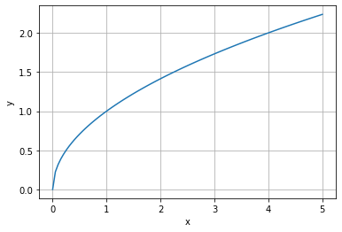

```python
import numpy as np
import matplotlib.pyplot as plt

x = np.linspace(0, 5, 100)
y = np.sqrt(x)

plt.figure()
plt.plot(x,y)
plt.grid()
plt.xlabel('x')
plt.ylabel('y')
```

**Question #9:** In Problem 9 through 17 the functions are defined in an interval about the given value of $a$ but not at $a$. Determine a value $\delta$ so that the given values of $L$ and $\varepsilon$, the statement "$|f(x)-L| < \varepsilon$ whenever $0 < |x-a| < \delta$" is valid. Sketch the graph of the given function.

- $f(x)=\frac{(x^{2}-9)}{(x+3)}$, $a=-3$, $L=-6$, $\varepsilon = 0.005$

**Solution:**
What is the domain? $x \ne -3$, so the domain is $\R \setminus \{-3\}$ What is the codomain? $$f(x)=\frac{(x^{2}-9)}{(x+3)}=\frac{(x+3)(x-3)}{(x+3)}=x-3$$ $f(-3)=-3-3=-6$, so exclude $-6$, the codomain is $\R \setminus \{-6\}$

By the definition of continuity, we get $$\Big|\frac{(x^{2}-9)}{(x+3)}-\frac{(x^{2}-9)}{(x+3)}\Big| < 0.005 \to -0.005 < \Big|\frac{(x^{2}-9)}{(x+3)}-\frac{((-3)^{2}-9)}{(-3+3)}\Big| < 0.005$$ $$\to -0.005 < \Big|(x-3)-(-3-3)\Big| < 0.005$$ $$\to 0.005 < (x-3)+6 < 0.005$$ $$\to -6.005 < x-3 < -5.995$$ $$\to -3.005 < x < -2.995$$

To find $\delta$, we use $\big|x-a\big| < \delta$, and we get $$\delta = min\big\{|-3.005+3|,|-2.995+3|\big\}=min\big\{0.005,0.005\big\}=0.005$$

Hence the $\delta = 0.005. \square$

Graphing of the function:

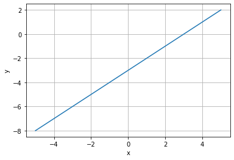

```python
x = np.linspace(-5, 5, 100)
y = (x**2 - 9)/(x+3)

plt.figure()
plt.plot(x,y)
plt.grid()
plt.xlabel('x')
plt.ylabel('y')
```

**Question #18:** Show that $\lim_{x \to 0} \sin{\frac{1}{x}}$ does not exist.

**Solution:** Simple solution: $\lim_{x \to 0} sin(\frac{1}{x})=sin(\frac{1}{0})=$ undefined. $\therefore$ the limit does not exist. $\square$

But let prove it. Let $f(x) = \sin{\frac{1}{x}}$, $a=0$ and be any $\varepsilon > 0$. By the definition of continuity, we get $$\Big|f(x)-f(a)\Big| < \varepsilon \to -\varepsilon < \Big|f(x)-f(a)\Big| < \varepsilon$$ $$\to -\varepsilon < f(x)-f(a) < \varepsilon$$ $$\to -\varepsilon+f(a) < f(x) < \varepsilon+f(a)$$ $$\to f^{-1}\big(-\varepsilon+f(a)\big) < x < f^{-1}\big(\varepsilon+f(a)\big)$$ $$\to f^{-1}\big(-\varepsilon+\sin{\frac{1}{0}}\big) < x < f^{-1}\big(\varepsilon+\sin{\frac{1}{0}}\big)$$ $$\to f^{-1}\big(-\varepsilon+undefined\big) < x < f^{-1}\big(\varepsilon+undefined\big)$$ $$\to undefined < x < undefined$$ $f(a)$ is undefined, as one cannot divide by zero, hence one cannot to find an $x$ value to find $\delta$ through $|x-a| < \delta$. By this reasoning, one can conclude that $\lim_{x \to 0} \sin{\frac{1}{x}}$ limit does not exist. $\square$

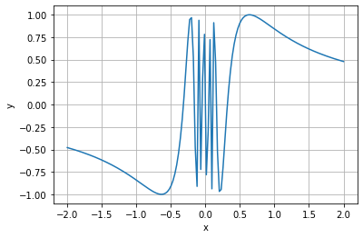

```python
x = np.linspace(-2, 2, 150)
y = np.sin(1/x)

plt.figure()
plt.plot(x,y)
plt.grid()
plt.xlabel('x')
plt.ylabel('y')
```